# **Humanities** in the Data Classroom

John R. Ladd

DH 2024, jrladd.com/slides/humanities-ds

# The *Future* of Code and Data Work

## Defining DH & CA

> On the one hand, it’s bringing the tools and techniques of digital media to bear on traditional humanistic questions. But it’s also bringing humanistic modes of inquiry to bear on digital media.

Kathleen Fitzpatrick, 2015

> [T]he computational study of culture. … [S]cholarship that applies computational and quantitative methods to the study of cultural objects (sound, image, text), cultural processes (reading, listening, searching, sorting, hierarchizing) and cultural agents (artists, editors, producers, composers).

Journal of Cultural Analytics

The non-humanities data science classroom is a place where we might “**bring humanistic modes of inquiry to bear**” on data analysis.

# Ways Humanities Data Can Intervene

## Foundational approaches

> [D]ata science is often framed as an abstract and technical pursuit. Steps like cleaning and wrangling data are presented as solely technical conundrums; there is less discussion of the social context, ethics, values, or politics of data. This perpetuates the myth that data science about astrophysics is the same as data science about criminal justice is the same as data science about carbon emissions. This limits the transformative work that can be done.

D’Ignazio and Klein, *Data Feminism* Ch. 2, 2020

> Data science educators around the world have begun to recognize the importance of human-centered approaches to the field to help students understand the risks and benefits of data science analysis (Anderson & Parker, 2019; Aragon et al., 2016;Wu et al., 2020). Integrating the humanities into the data science curriculum could also provide a road to a “science identity” for students who lack one, by spotlighting the type of creative and big-picture thinking that such students fear the discipline is missing (Sjøberg, 2002; Steele et al., 1974; Tobias, 1993; Valenti et al., 2016).

Eric A. Vance, et al., “Integrating the Humanities into Data Science Education: Reimagining the Introductory Data Science Course”

## Ethics and Data in Context

[figure not shown]

## Unstructured Data

[figure not shown]

## Familiarity

[figure not shown]

## Problem Formulation

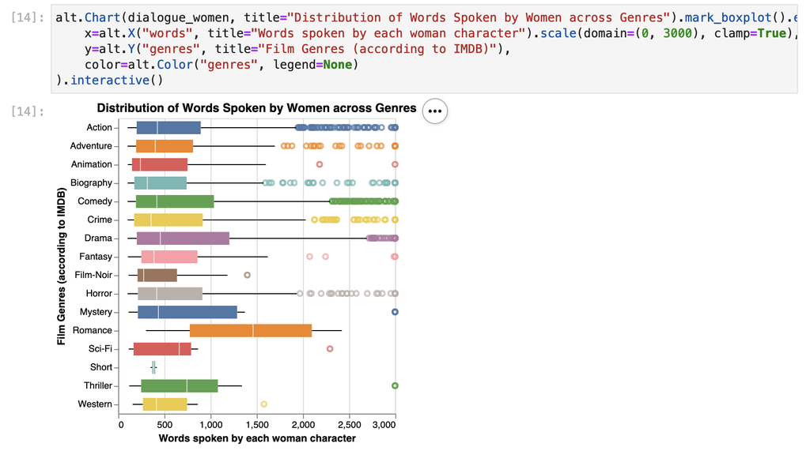

## DS as a *discipline*

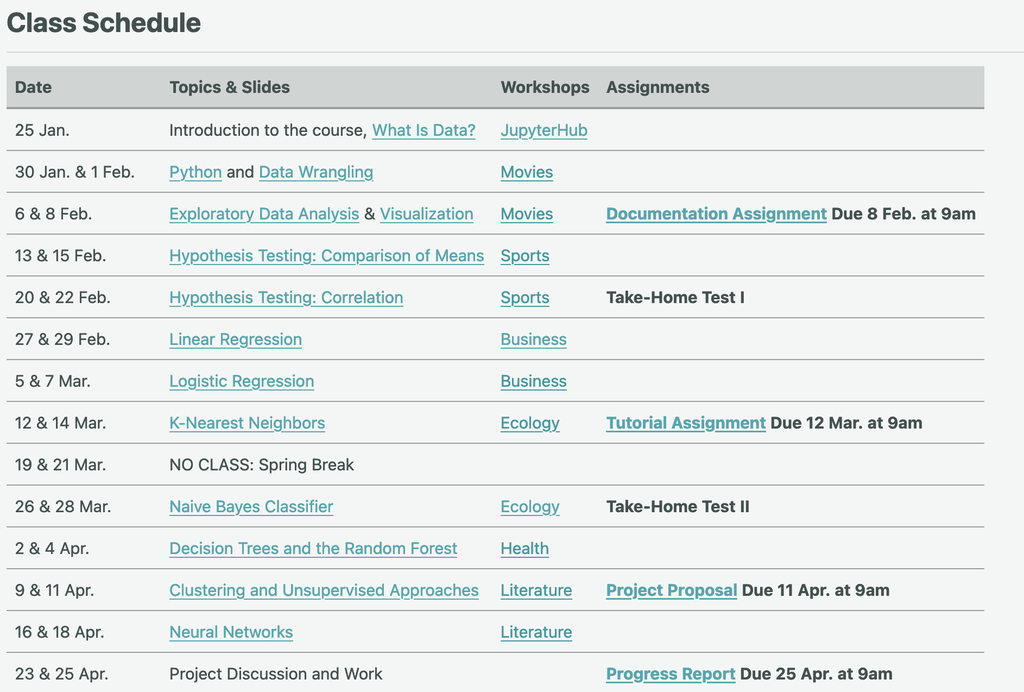

# Humanities data isn’t an “extra”

It’s an essential part of data literacy education and introducing undergraduates to code and data work.